# Data Exploration - Fall 2024

### **Week 2: Reading and Summarizing Data in R**

Melissa Laurino & Dr. Clif Baldwin - September 12, 2024

In comparison to an R Script (.R file extension), this is an [R Markdown](http://rmarkdown.rstudio.com) Notebook (.Rmd file extension). When you execute code within the notebook, the results appear beneath the code. When you save the notebook, an HTML file (nb.html file extension) containing the code and output will be saved alongside it.

Follow along with this example by joining my Github repository: https://github.com/MelissaLaurino/DSSA-5101_Fall2024/tree/main/Week%201%20-%20Reading%20and%20Summarizing%20Data%20in%20R

- Download the .csv file
- Download the blank R Script
  - Or create your own from scratch: File -> New File -> R Script

#### Background Information:

Cetaceans, whales and dolphins, inhabit inshore and offshore waters of New Jersey. A stranding is defined as an event that occurs in the wild when a marine mammal is found dead on the shore or floating along the shore in United States coastal waters. Strandings occur as a single stranding that involves one individual or a mass stranding that involves many animals due to disease, human interaction or other unknown factors. Data was obtained from the North East division of the [National Marine Fisheries Service (NMFS)](https://www.fisheries.noaa.gov/national/marine-life-distress/national-stranding-database-public-access) for all marine mammal strandings in the states of New Jersey and Delaware from January 2000-October 2017. Marine mammals are federally protected species under the Marine Mammal Protection Act of 1972. Data was collected using [Level A](https://media.fisheries.noaa.gov/dam-migration/level_a_form_2023_opr2pdf.pdf) stranding reports with trained professionals of the Marine Mammal Stranding Center in New Jersey and the MERR Institute in Delaware. Stranding data provides important details to understand the morphology, life history, biology, and general health of marine mammals. It may also detect environmental threats and negative human impacts that may have conservation implications.

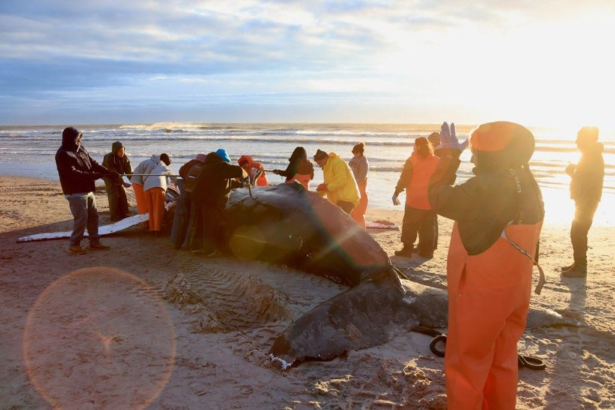

National Marine Fisheries Service, Department of Commerce (2017). Marine Mammal Health and Stranding Response Database [2000-2017_StrandingData.csv].

#### Read in data using R:

Our data is stored as a .csv file. A comma separated value (.csv) file uses commas to separate values. There are no formulas, formatting, comments, etc., in a csv file. If you save an Excel file as a CSV file, the formulas, formatting and comments in your file will disappear to just represent the values. We need to read the CSV file into R as a data frame to be able to work with it.  
In order to read in your .csv file of data into R, it needs to be found within the same folder you have this document saved. If that is not the case, you will need to set your working directory:

```r
# Get your working directory. Your working directory is the path to this file. This may look different for PC users/Mac users.
getwd()
```

```
[1] "/Users/melissa/Documents/DSSA/Data Exploration"
```

If the above path is not where you have your .csv data file saved, you will need to set your working directory. To obtain the path for where your file is located:

Mac: Right click on the folder -> Get Info -> Copy as path name:

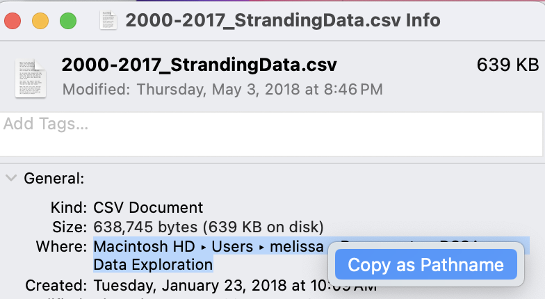

Windows: Double click on the path bar and it will reformat to copy and paste:

[figure not shown]

For this example, you can avoid this step by manually moving the data file where your R script is saved :)

**Read in the data using read.csv()**

```r
# Read in the data from the .csv file:
# Use TAB to auto complete
# Header = TRUE because our data has headers (Column names)
stranding <- read.csv("2000-2017_StrandingData.csv", header = TRUE)
```

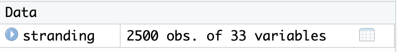

The variable “stranding” has 2500 rows and 33 columns of data as seen in your R environment.

We can also get this same information by checking the dimensions of our data:

```r
dim(stranding)
```

```
[1] 2500   33
```

Our data has 2500 rows and 33 columns.

**Summarize your data**

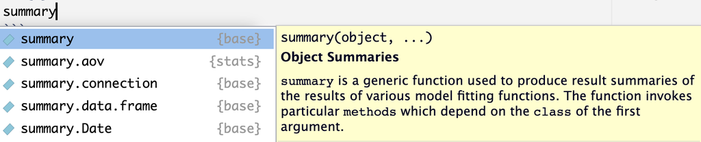

When you start to type in a function, you can press TAB to have R auto complete with a list of options and short description.

```r
# Summarize your entire data
summary(stranding)
```

```
 NationalDatabaseNumber   Species             Region            Country          City.fromstrandingstable
 Length:2500            Length:2500        Length:2500        Length:2500        Length:2500
 Class :character       Class :character   Class :character   Class :character   Class :character
 Mode  :character       Mode  :character   Mode  :character   Mode  :character   Mode  :character




    County             State           BodyofWater        LocalityDetail       Latitude
 Length:2500        Length:2500        Length:2500        Length:2500        Length:2500
 Class :character   Class :character   Class :character   Class :character   Class :character
 Mode  :character   Mode  :character   Mode  :character   Mode  :character   Mode  :character




 ConversionLAT   LatitudeUnits      LatitudeActualEstimate  Longitude         ConversionLONG
 Min.   :36.77   Length:2500        Length:2500            Length:2500        Min.   :-80.23
 1st Qu.:39.02   Class :character   Class :character       Class :character   1st Qu.:-74.85
 Median :39.41   Mode  :character   Mode  :character       Mode  :character   Median :-74.37
 Mean   :39.50                                                                Mean   :-74.48
 3rd Qu.:39.98                                                                3rd Qu.:-74.07
 Max.   :53.86                                                                Max.   :-72.32
 NA's   :16                                                                   NA's   :16
 LongitudeUnits     LongitudeActualEstimate Howlatlongdetermined ObservationDate      SickFlag
 Length:2500        Length:2500             Length:2500          Length:2500        Length:2500
 Class :character   Class :character        Class :character     Class :character   Class :character
 Mode  :character   Mode  :character        Mode  :character     Mode  :character   Mode  :character




 InjuredFlag        OutofHabitatFlag   DeemedHealthyReleasableFlag AbandonedOrphanedFlag InaccesibleFlag
 Length:2500        Length:2500        Length:2500                 Length:2500           Length:2500
 Class :character   Class :character   Class :character            Class :character      Class :character
 Mode  :character   Mode  :character   Mode  :character            Mode  :character      Mode  :character




 LocationHazardoustoAnimal LocationHazardousPublic UnknownCBDFlag     ConditionOtherFlag
 Length:2500               Length:2500             Length:2500        Length:2500
 Class :character          Class :character        Class :character   Class :character
 Mode  :character          Mode  :character        Mode  :character   Mode  :character




 ConditionOtherDescription EntangledFlag      Sex              AgeClass
 Length:2500               Mode:logical   Length:2500        Length:2500
 Class :character          NA's:2500      Class :character   Class :character
 Mode  :character                         Mode  :character   Mode  :character
```

Summarizing your data will give you different results based on the data types within your columns. For example, numerical data types will give you the minimum, maximum, and median of your vector. Character columns are text columns. For large data sets, you can view the first few rows by using the head() function:

```r
# View only the first 6 rows of data
head(stranding)
```

|  | NationalDatabaseNumber | Species | Region | Country | City.fromstrandingstable | County | State | BodyofWater | LocalityDetail | Latitude | ConversionLAT | LatitudeUnits | LatitudeActualEstimate | Longitude | ConversionLONG | LongitudeUnits | LongitudeActualEstimate | Howlatlongdetermined | ObservationDate | SickFlag | InjuredFlag | OutofHabitatFlag | DeemedHealthyReleasableFlag | AbandonedOrphanedFlag | InaccesibleFlag | LocationHazardoustoAnimal | LocationHazardousPublic | UnknownCBDFlag | ConditionOtherFlag | … |
| --- | --- | --- | --- | --- | --- | --- | --- | --- | --- | --- | --- | --- | --- | --- | --- | --- | --- | --- | --- | --- | --- | --- | --- | --- | --- | --- | --- | --- | --- | --- |
| 1 | NE-2008-1078763 | grypus | NE | United States | Bethany Beach | Sussex | DE | Atlantic Ocean | Between 3rd and 4th street | 38.544716 | 38.54472 | decimal degrees | actual | -75.05495 | -75.05495 | decimal degrees | actual | GPS | 2008-MAR-14 | Y | Y | N | N | N | N | N | N | N | N | … |
| 2 | NE-2004-1040109 | truncatus | NE | United States | Ocean City | Cape May | NJ | Atlantic Ocean | 51st St and the beach | 391345 | 39.22917 | deg/min/sec | actual | 743745 | -74.62917 | deg/min/sec | actual | Other | 2004-SEP-23 | N | N | N | N | N | N | N | N | N | N | … |
| 3 | NE-2008-1077359 | delphis | NE | United States | Ocean | Cape May | NJ | Atlantic Ocean | Corsons Inlet State Park, 1/4 mile south of 59th street beach access. | 39.214151 | 39.21415 | decimal degrees | estimate | -74.64147 | -74.64147 | decimal degrees | estimate | Internet | 2008-APR-26 | Y | N | N | N | N | N | N | N | N | N | … |
| 4 | NE-2008-1074989 | groenlandica | NE | United States | Wildwood Crest | Cape May | NJ | Atlantic Ocean | Toledo Ave and the beach | 38.962126 | 38.96213 | decimal degrees | estimate | -74.83931 | -74.83931 | decimal degrees | estimate | Internet | 2008-MAR-02 | Y | N | N | N | N | N | N | N | N | N | … |
| 5 | NE-2008-1077357 | delphis | NE | United States | Avalon | Cape May | NJ | Atlantic Ocean | 69th street and the beach | 39.069541 | 39.06954 | decimal degrees | estimate | -74.741313 | -74.74131 | decimal degrees | estimate | Internet | 2008-APR-26 | N | N | N | N | N | N | N | N | N | N | … |
| 6 | NE-2007-1072223 | truncatus | NE | United States | Lewes | Sussex | DE | Delaware Bay | Floating near inner breakwall off of Cape Henlopen State Park |  | NA | decimal degrees |  |  | NA | decimal degrees |  |  | 2007-JUL-01 | N | N | N | N | N | N | N | N | N | N | … |

**List the column names of your data:**

When exploring data, it is important to take the time to UNDERSTAND the data as well. A lot of this information can be found in the metadata. Metadata is data about the data. How was the data collected? What data collection procedures are important to know when trying to answer questions about your data? What are the units of a column? Are columns measured as categorical values or numerical values? The [Level A](https://media.fisheries.noaa.gov/dam-migration/level_a_form_2023_opr2pdf.pdf) stranding data sheet has about 60 columns of data per animal stranding, but when I made this data request, I only requested the 33 listed below. The stranding data sheet has the answers to some of the example questions stated above.

```r
# List column names within your data
names(stranding)
```

```
 [1] "NationalDatabaseNumber"      "Species"                     "Region"
 [4] "Country"                     "City.fromstrandingstable"    "County"
 [7] "State"                       "BodyofWater"                 "LocalityDetail"
[10] "Latitude"                    "ConversionLAT"               "LatitudeUnits"
[13] "LatitudeActualEstimate"      "Longitude"                   "ConversionLONG"
[16] "LongitudeUnits"              "LongitudeActualEstimate"     "Howlatlongdetermined"
[19] "ObservationDate"             "SickFlag"                    "InjuredFlag"
[22] "OutofHabitatFlag"            "DeemedHealthyReleasableFlag" "AbandonedOrphanedFlag"
[25] "InaccesibleFlag"             "LocationHazardoustoAnimal"   "LocationHazardousPublic"
[28] "UnknownCBDFlag"              "ConditionOtherFlag"          "ConditionOtherDescription"
[31] "EntangledFlag"               "Sex"                         "AgeClass"
```

From the 33 columns of data, we can choose a specific one or two to summarize if we do not want to summarize all of the data:

```r
# Summarize only a specific column by name using $ in your syntax
summary(stranding$ConversionLAT)
```

```
   Min. 1st Qu.  Median    Mean 3rd Qu.    Max.    NA's
  36.77   39.02   39.41   39.50   39.98   53.86      16
```

```r
summary(stranding$ConversionLONG)
```

```
   Min. 1st Qu.  Median    Mean 3rd Qu.    Max.    NA's
 -80.23  -74.85  -74.37  -74.48  -74.07  -72.32      16
```

```r
# Summarize only a specific column by name using $ in your syntax
summary(stranding$Species)
```

```
   Length     Class      Mode
     2500 character character
```

#### Explore your data using libraries:

There are many different libraries that are useful for working with your data. Many of these work together with each other and the base R functions.

[tidyverse](https://tidyverse.tidyverse.org/) - A collection of packages to explore and manipulate your data

- [dplyr](https://dplyr.tidyverse.org/) - Manipulating your data by filtering and rearranging
- [lubridate](https://lubridate.tidyverse.org/) - Working with dates and times in your data
- [readr](https://readr.tidyverse.org) - Importing data in multiple different formats
- [ggplot2](https://ggplot2.tidyverse.org) - Basic graphs for data visualisation

Installing a package into R:

```r
#install.packages("tidyverse")
library(tidyverse)
```

After running install.packages() once, you can comment it out. If you run it a second time at a later date, it will update it as needed or return an error that it is already installed. With tidyverse, we can now summarize our data with additional functions. We can use glimpse() to view another data summary that is more detailed for character columns. Notice how we can now view some of the character data within the columns.

```r
glimpse(stranding)
```

```
Rows: 2,500
Columns: 33
$ NationalDatabaseNumber      <chr> "NE-2008-1078763", "NE-2004-1040109", "NE-2008-1077359", "NE-2008-1074989", "NE-2…
$ Species                     <chr> "grypus", "truncatus", "delphis", "groenlandica", "delphis", "truncatus", "trunca…
$ Region                      <chr> "NE", "NE", "NE", "NE", "NE", "NE", "NE", "NE", "NE", "NE", "NE", "NE", "NE", "NE…
$ Country                     <chr> "United States", "United States", "United States", "United States", "United State…
$ City.fromstrandingstable    <chr> "Bethany Beach", "Ocean City", "Ocean", "Wildwood Crest", "Avalon", "Lewes", "Mil…
$ County                      <chr> "Sussex", "Cape May", "Cape May", "Cape May", "Cape May", "Sussex", "Sussex", "Su…
$ State                       <chr> "DE", "NJ", "NJ", "NJ", "NJ", "DE", "DE", "DE", "DE", "DE", "DE", "DE", "DE", "DE…
$ BodyofWater                 <chr> "Atlantic Ocean", "Atlantic Ocean", "Atlantic Ocean", "Atlantic Ocean", "Atlantic…
$ LocalityDetail              <chr> "Between 3rd and 4th street", "51st St and the beach", "Corsons Inlet State Park,…
$ Latitude                    <chr> "38.544716", "391345", "39.214151", "38.962126", "39.069541", "", "", "38.821", "…
$ ConversionLAT               <dbl> 38.54472, 39.22917, 39.21415, 38.96213, 39.06954, NA, NA, 38.82100, 38.77542, NA,…
$ LatitudeUnits               <chr> "decimal degrees", "deg/min/sec", "decimal degrees", "decimal degrees", "decimal …
$ LatitudeActualEstimate      <chr> "actual", "actual", "estimate", "estimate", "estimate", "", "", "actual", "actual…
```

[output cut: 20 more lines]

You can select a specific column within the stranding data frame by specifying the column name, Species. Note that we are not saving a new data frame as a variable to use later, we are just viewing it at this time.

```r
select(stranding, Species)
```

| Species |
| --- |
| grypus |
| truncatus |
| delphis |
| groenlandica |
| delphis |
| truncatus |
| truncatus |
| phocoena |
| grypus |
| phocoena |

[output cut: 990 more lines]

Now let’s say we want to look at all of the times a specific species was observed stranded. We can filter for the Bottlenose dolphin, or *Tursiops truncatus*, by specifying to filter for *truncatus*. The genus name is *Tursiops* and the species name is *truncatus*. This data set specifies a specific species by indicating just the species name.

We can select for Bottlenose dolphins by using the operator ==, specifying for *truncatus*. It will now only show us entries when Bottlenose dolphins stranded.

```r
# Use filter to select for a specific species, truncatus, within the column Species
filter(stranding, Species == "truncatus")
```

| NationalDatabaseNumber | Species | Region | Country | City.fromstrandingstable | County | State | BodyofWater | LocalityDetail | Latitude | ConversionLAT | LatitudeUnits | LatitudeActualEstimate | Longitude | ConversionLONG | LongitudeUnits | LongitudeActualEstimate | Howlatlongdetermined | ObservationDate | SickFlag | InjuredFlag | OutofHabitatFlag | DeemedHealthyReleasableFlag | AbandonedOrphanedFlag | InaccesibleFlag | LocationHazardoustoAnimal | LocationHazardousPublic | UnknownCBDFlag | ConditionOtherFlag | ConditionOtherDescription | … |
| --- | --- | --- | --- | --- | --- | --- | --- | --- | --- | --- | --- | --- | --- | --- | --- | --- | --- | --- | --- | --- | --- | --- | --- | --- | --- | --- | --- | --- | --- | --- |
| NE-2004-1040109 | truncatus | NE | United States | Ocean City | Cape May | NJ | Atlantic Ocean | 51st St and the beach | 391345 | 39.22917 | deg/min/sec | actual | 743745 | -74.62917 | deg/min/sec | actual | Other | 2004-SEP-23 | N | N | N | N | N | N | N | N | N | N |  | … |
| NE-2007-1072223 | truncatus | NE | United States | Lewes | Sussex | DE | Delaware Bay | Floating near inner breakwall off of Cape Henlopen State Park |  | NA | decimal degrees |  |  | NA | decimal degrees |  |  | 2007-JUL-01 | N | N | N | N | N | N | N | N | N | N |  | … |
| NE-2007-1072221 | truncatus | NE | United States | Milford | Sussex | DE | Delaware Bay | South Slaughter Beach; Simpson St. |  | NA | decimal degrees |  |  | NA | decimal degrees |  |  | 2007-AUG-20 | N | N | N | N | N | N | N | N | N | N |  | … |
| NE-2007-1072211 | truncatus | NE | United States | Fenwick Island | Sussex | DE | Atlantic Ocean | 1 mile south of Fenwick Island State Park | 38.46968 | 38.46968 | decimal degrees | actual | -75.0496166 | -75.04962 | decimal degrees | actual | GPS | 2007-JUN-10 | N | N | N | N | N | N | N | N | N | N |  | … |
| NE-2007-1072213 | truncatus | NE | United States | Fenwick Island | Sussex | DE | Atlantic Ocean | Fenwick Island State Park | 38.477066 | 38.47707 | decimal degrees | actual | -75.050233 | -75.05023 | decimal degrees | actual | GPS | 2007-JUN-14 | N | N | N | N | N | N | N | N | N | N |  | … |
| NE-2007-1072215 | truncatus | NE | United States | Fenwick Island | Sussex | DE | Atlantic Ocean |  | 38.45942 | 38.45942 | decimal degrees | actual | -75.04928 | -75.04928 | decimal degrees | actual | GPS | 2007-AUG-01 | N | N | N | N | N | N | N | N | N | N |  | … |
| NE-2007-1071721 | truncatus | NE | United States | Pt. Pleasant Beach | Ocean | NJ | Atlantic Ocean | Ocean Ave.and the beach, between Philadelphia Ave and Washington Ave | 40.085703 | 40.08570 | decimal degrees | estimate | -74.037795 | -74.03780 | decimal degrees | estimate | Internet | 2007-NOV-03 | N | N | N | N | N | N | N | N | N | N |  | … |
| NE-2004-1054345 | truncatus | NE | United States | Dewey | Sussex | DE | Atlantic Ocean | north of indian river inlet on the beach at tide line | 38 38.677 | 38.64462 | decimal minutes | actual | 075 03.923 | -75.06538 | decimal minutes | actual | GPS | 2004-MAY-30 | N | N | N | N | N | N | N | N | N | N |  | … |
| NE-2000-1033490 | truncatus | NE | United States | REHOBOTH | Sussex | DE | Atlantic Ocean | GORDON"S POND AREA OF CAPE HENLOPEN SP, 100 YDS N. OF TOWERS (ATLANTIC OCEAN) | 3844.27 | 38.73783 | decimal degrees |  | 7504.68 | -75.07800 | decimal degrees |  |  | 2000-JUL-25 | N | N | N | N | N | N | N | N | N | N |  | … |
| NE-2001-1033155 | truncatus | NE | United States | WILDWOOD CREST | Cape May | NJ | Atlantic Ocean | PUBLIC WORKS DEPARTMENT, WASHINGTON AVENUE | 385756 | 38.96556 | deg/min/sec |  | 745116 | -74.85444 | deg/min/sec |  |  | 2001-SEP-18 | N | N | N | N | N | N | N | N | N | N |  | … |

[output cut: 645 more lines]

What if we did not have our data as a CSV file? We can read Excel files too, and there are many library options for multiple different file formats. Let’s install readxl as recommended by [R for Data Science](https://r4ds.hadley.nz/spreadsheets).

```r
# Install package readxl as recommended by R for Data Science
# https://r4ds.hadley.nz/spreadsheets
# install.packages("readxl")

#Load the package
library(readxl)

#Load the data
stranding_excel <- read_xls("2000-2017_StrandingData.xls",col_names = TRUE)
```

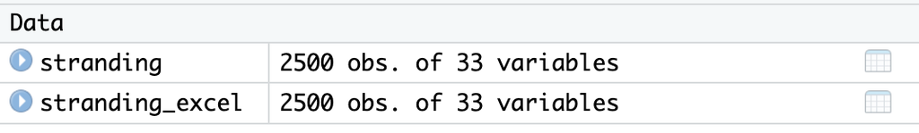

The new variable “stranding_excel” has 2500 rows and 33 columns of data as seen in your R environment just like our original variable. The library readxl can also be used to read in .csv files using function read_csv()

#### Homework for Week 2

R Programming for Data Science (ch. 6, 7, 10, 11)

Reading csv files the Core R way: https://swcarpentry.github.io/r-novice-inflammation/11-supp-read-write-csv/

Wickham, H. (2014). Tidy Data. Journal of Statistical Software, 59(10), 1 - 23. doi:http://dx.doi.org/10.18637/jss.v059.i10

Teaching the Tidyverse in 2021 https://www.tidyverse.org/blog/2021/08/teach-tidyverse-2021/ R Notebook in RStudio http://rmarkdown.rstudio.com/r_notebooks.html

**R Mini Project 1**: Instructions posted to Blackboard. Due Week 4.

```r
#Remove stranding_excel data frame
rm(stranding_excel)
```

### **Week 3: Data Types in R**

Melissa Laurino & Dr. Clif Baldwin - September 19, 2024

We will continue working with the marine mammal stranding data introduced last week for these examples.

Follow along with this example by joining my Github repository: https://github.com/MelissaLaurino/DSSA-5101_Fall2024/tree/main/Week%201%20-%20Reading%20and%20Summarizing%20Data%20in%20R

- Download the .csv file
- Download the blank R Script
  - Create your own from scratch: File -> New File -> R Script
  - Or continue from your script last week (Recommended)!

#### Different Data Types

By taking a glimpse at the data, we can see the data types that are assigned to each column of data within the data frame stranding.

```r
# Use glimpse() to view the data:
glimpse(stranding)
```

[output not shown]

[output cut: 21 more lines]

- **Numeric**: Integers and doubles

  ```
  <int> Integers - Number data, count, or measurement data Ex) Water temperature, depth
  <dbl> Doubles - Continuous numbers with decimal points Ex) Lattitude and Longitude coordinates
  ```

- **Character**: Strings

  ```
  <chr> Text or string values - Ex) Species name, location name
  ```

- **Logical**: Boolean values (`TRUE` or `FALSE`)

  ```
  <lgl> 1 or 0
  ```

- **Factor**: A type of **vector** that includes categorical data, often used for grouping

  ```
  <fct> Ex) Species, Sex, AgeClass - These columns are showing as character columns, but they can be renamed as factors.
  ```

- **Date and Time**:

  ```
  <date> Date Ex) ObservationDate
  <dttm> Time, or sometimes the date and time together in one column
  ```

#### Vectors and Factors

Vectors are manually specified using c(). We can input our data to create a vector from scratch using c().

```r
?c()
```

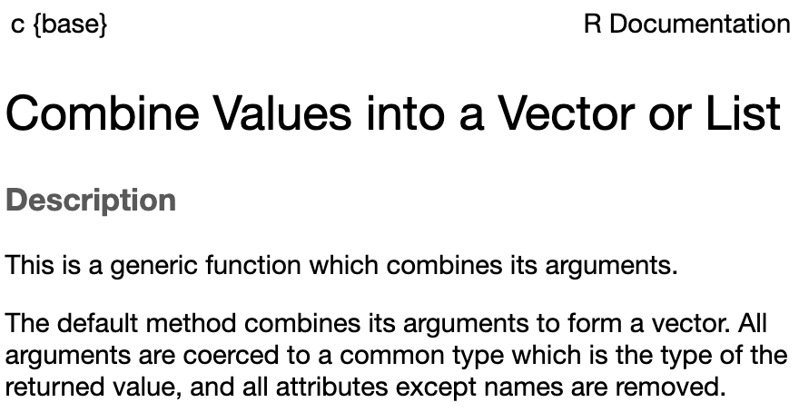

```r
# Manually create a vector of professor last names:
professors <- c("Baldwin", "Dunn", "Laurino", "Olsen", "Sokol", "Trout")

professors
```

```
[1] "Baldwin" "Dunn"    "Laurino" "Olsen"   "Sokol"   "Trout"
```

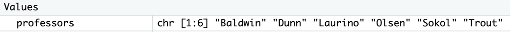

We can now see the vector under Values in our environment.

Since we already have our data, we can use our Species column. The Species column is shown as a Character column, but we can convert this column to a **Factor** instead. Factors are special vectors that store the data as categorical values, which is what we have in the Species column.

Before we get started, we can remove the vector we just created.

```r
rm(professors)
```

professors is now no longer under Values in our environment.

```r
# Create a vector from the Species column:
species_vector <- stranding$Species
# If we print the vector, you'll see a vector of the Species column, similar to what we saw with the professor vector.
# species_vector

# Convert the vector to a factor using factor()
species_factor <- factor(species_vector)
```

We have two options here, we can replace the current Species column within the stranding data frame as a factor, OR we can create a new column in the data frame. The benefits of creating a new column is preserving the original data. Creating a new column allows us to group this data for potential graphing or looking at the counts of species that have stranded.

```r
# Add the factor as a NEW column in the data frame, stranding:
stranding$Species_factor <- species_factor
```

We added a new column to our data frame, now displaying 34 variables within our environment, but we **did not write the changes to the .csv file** at this time. If you open your .csv file in Excel, you will not see an additional column. We just created a new column in our R data frame at this time.

[figure not shown]

Now displaying 34 variables instead of 33.

```r
str(stranding$Species_factor)
```

```
 Factor w/ 34 levels "","acutorostrata",..: 22 32 14 21 14 32 32 29 22 29 ...
```

We have successfully added a new column to our data as a factor instead of character values.

#### Lists

Lists can hold different sizes and types of data such as characters, vectors, factors, integers, additional lists, etc. at the same time.

```r
# Summary statistics for the Latitude column
latitude_summary <- summary(stranding$ConversionLAT)

# Summary statistics for the Longitude column
longitude_summary <- summary(stranding$ConversionLONG)

# Create a list() with the above values, plus the species factor we created before:
stranding_list <- list(species_factor, latitude_summary, longitude_summary)

# Print the list
stranding_list
```

[output not shown]

Now we have a list of different data from our data frame.

```r
# Assign names to our new list of data
names(stranding_list) <- c("Species Stranded", "Latitude Summary", "Longitude Summary")

# View the list
print(stranding_list)
```

[output not shown]

With this specific data set, we would not need this list, but maybe we could find a use for it :) If we had multiple different data frames, we could pull data from separate data frames to create a unique list.

#### Matrices

Matrices can only hold the **same** types of data, such as integers. We can manually create a 2x6 matrix of the summary statistics of the latitude and longitude we obtained earlier.

```r
# Manually create a matrix using the values from the summary of the latitudes and longitudes:
matrix <- matrix(c(36.77, 39.02, 39.41, 39.50, 39.98, 53.86, -80.23, -74.85, -74.37,  -74.48, -74.07, -72.32), nrow = 2, byrow = TRUE)

# View the matrix
matrix
```

```
       [,1]   [,2]   [,3]   [,4]   [,5]   [,6]
[1,]  36.77  39.02  39.41  39.50  39.98  53.86
[2,] -80.23 -74.85 -74.37 -74.48 -74.07 -72.32
```

Name the rows of your matrix:

```r
# Name the rows of the matrix
rownames(matrix) <- c("Latitude", "Longitude")

# View the matric with the added row names
matrix
```

```
            [,1]   [,2]   [,3]   [,4]   [,5]   [,6]
Latitude   36.77  39.02  39.41  39.50  39.98  53.86
Longitude -80.23 -74.85 -74.37 -74.48 -74.07 -72.32
```

Name the columns of your matrix:

```r
# Name the columns of the matrix
colnames(matrix) <- c("Min", "1st Qu.", "Median", "Mean", "3rd Qu.", "Max")

# View the matrix with the added column names
matrix
```

```
             Min 1st Qu. Median   Mean 3rd Qu.    Max
Latitude   36.77   39.02  39.41  39.50   39.98  53.86
Longitude -80.23  -74.85 -74.37 -74.48  -74.07 -72.32
```

Determine specific values from your matrix:

```r
# What is the median of the Latitude in our matrix?
matrix["Latitude", "Median"]
```

```
[1] 39.41
```

```r
# What is the maximum value of the Longitude in our matrix?
matrix["Longitude", "Max"]
```

```
[1] -72.32
```

#### Homework for Week 3

R Programming for Data Science, chapter 5

Understanding Data https://www.r-bloggers.com/understanding-data/amp/

Working With Vectors https://www.r-bloggers.com/working-with-vectors/

Vectors and Functions https://www.r-bloggers.com/vectors-and-functions/

Tibbles https://www.r-bloggers.com/a-tour-of-the-tibble-package/

“Examine a Data Frame in R with 7 Basic Functions” https://rveryday.wordpress.com/2016/11/29/examine-a-data-frame-in-r-with-7-basic-functions/

Creating vectors https://www.r-exercises.com/2019/07/29/creating-vectors/

**R Mini Project 1**: Instructions posted to Blackboard. Due Week 4.